# GSEA原理及其在微生物组数据的广义化应用

## GSEA前导边缘分析：识别核心驱动样本

Leading Edge Analysis（前导边缘分析）是GSEA结果解读中至关重要的一步,能够帮助我们定位哪些具体元素对富集信号贡献最大。

### 前导边缘子集的定义

前导边缘子集（Leading Edge Subset）被定义为：从排序列表的起始位置开始，一直到出现富集分数最大值（Peak）的那一刻为止，在此区间内出现的所有属于该特征集合的成员。

在经典的基因集富集分析中，这些成员是基因；而在本文介绍的**样本级富集分析**中，这些成员是**样本ID**。前导边缘子集被认为是该特征集合富集信号的核心贡献者。

### 在微生物组分析中的意义

在微生物群落分析场景中，前导边缘样本具有特殊的生物学意义：

**识别关键宿主样本：** 当我们发现某个样本特征（如”患病组”）在某个菌的高丰度端显著富集时，前导边缘子集包含的样本ID就是该菌丰度最极端的核心样本。这些样本可能代表了疾病最严重的个体，或是环境因子作用最强烈的生态位。

**筛选代表性样本：** 在后续的深度测序、代谢组学或其他高成本分析中，可以优先选择前导边缘样本进行验证，因为它们最能代表该特征与目标菌丰度之间的关联模式。

### 提取前导边缘样本

在使用 `fgsea` 包进行分析时，结果表格中已经自动包含了一个名为 `leadingEdge` 的列。这一列是一个列表（List）结构，存储了每个特征集合的具体核心样本ID。

```r
# 假设 fgseaRes 是之前运行得到的结果对象
# 1. 查看结果表结构，注意 leadingEdge 列
head(fgseaRes)
```

```
##            pathway         pval         padj    log2err         ES        NES
##             <char>        <num>        <num>      <num>      <num>      <num>
## 1:   Group_Control 8.471189e-08 3.388475e-07 0.70497572 -0.8474911 -2.7103134
## 2: Group_Treatment 1.896680e-07 3.793361e-07 0.69013246  0.8730745  2.5942035
## 3:    Source_Fecal 9.763113e-01 9.763113e-01 0.03911552  0.1816169  0.5533213
## 4:     Source_Oral 6.013865e-01 8.018486e-01 0.06266182  0.2937660  0.8920200
##     size                                                    leadingEdge
##    <int>                                                         <list>
## 1:    30 Sample_9,Sample_19,Sample_39,Sample_20,Sample_18,Sample_31,...
## 2:    20   Sample_28,Sample_4,Sample_6,Sample_27,Sample_8,Sample_35,...
## 3:    27  Sample_28,Sample_4,Sample_8,Sample_22,Sample_11,Sample_10,...
## 4:    23     Sample_6,Sample_27,Sample_35,Sample_32,Sample_12,Sample_48
```

```r
# 2. 提取富集最显著特征的前导边缘样本
# 先按 NES 降序排列，取第一行
top_feature_info <- fgseaRes %>%
  arrange(desc(NES)) %>%
  slice(1)

# 获取特征名称
feature_name <- top_feature_info$pathway

# 获取 Leading Edge 样本列表 (这是一个 list 元素，需要 unlist)
core_samples <- unlist(top_feature_info$leadingEdge)

# 打印结果
cat("Top Feature:", feature_name, "\n")
```

```
## Top Feature: Group_Treatment
```

```r
cat("Number of Core Samples:", length(core_samples), "\n")
```

```
## Number of Core Samples: 15
```

```r
cat("Core Sample IDs:\n")
```

```
## Core Sample IDs:
```

```r
print(core_samples)
```

```
##  [1] "Sample_28" "Sample_4"  "Sample_6"  "Sample_27" "Sample_8"  "Sample_35"
##  [7] "Sample_32" "Sample_22" "Sample_12" "Sample_48" "Sample_11" "Sample_13"
## [13] "Sample_17" "Sample_43" "Sample_40"
```

```r
# 3. 提取这些核心样本的丰度值进行进一步分析
core_sample_abundance <- abundance_zscore[core_samples]
cat("\nAbundance distribution of core samples:\n")
```

```
##
## Abundance distribution of core samples:
```

```r
summary(core_sample_abundance)
```

```
##    Min. 1st Qu.  Median    Mean 3rd Qu.    Max.
##  0.3488  0.8236  1.2385  1.2063  1.6627  1.8542
```

### 可视化前导边缘的重叠

当发现多个样本特征显著富集时，可以使用 UpSet 图来展示它们的前导边缘样本是否存在重叠。这能回答一个重要问题：**不同的样本特征是否由同一批核心样本驱动？**

```r
library(UpSetR)

# 1. 筛选显著富集的特征（例如 padj < 0.05）
sig_features <- fgseaRes %>%
  filter(padj < 0.05) %>%
  arrange(desc(abs(NES)))

# 如果显著特征太多，只取前5个
if(nrow(sig_features) > 5) {
  sig_features <- sig_features %>% head(5)
}

# 2. 构建 UpSetR 需要的列表数据
# 列表名为特征名，列表内容为该特征的 leadingEdge 样本
list_for_upset <- setNames(sig_features$leadingEdge, sig_features$pathway)

# 3. 绘制 UpSet 图
# 这张图能清晰展示哪些样本是多个特征共有的（关键驱动样本）
upset(fromList(list_for_upset),
      order.by = "freq",
      main.bar.color = "steelblue",
      sets.bar.color = "darkgreen")
```

```
## `geom_line()`: Each group consists of only one observation.
## ℹ Do you need to adjust the group aesthetic?
```

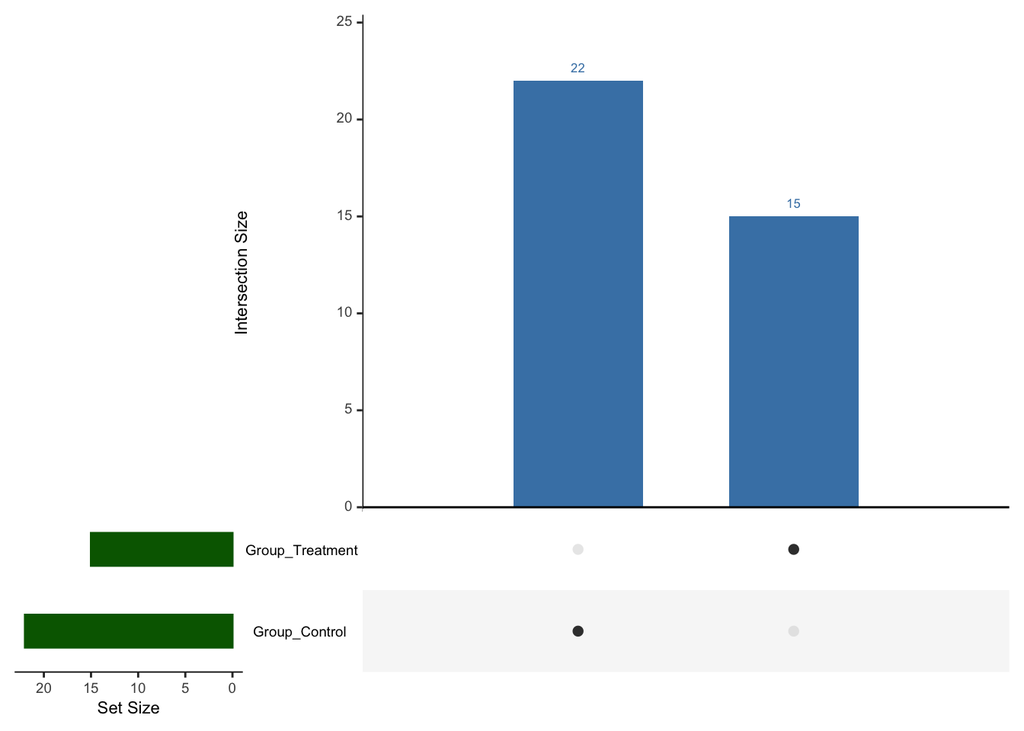

### 结果解读

**交集部分（Intersection）：** 如果多个特征的前导边缘样本存在大量重叠，说明这些样本同时具备多种极端特征。例如，某些样本可能既属于”高pH环境”又属于”患病组”的前导边缘，暗示这些特征可能协同影响目标菌的丰度分布。

**特有部分：** 仅属于某一个特征的前导边缘样本，则代表了该特征的独特影响。这些样本可以帮助我们区分不同环境因子或临床指标的独立效应。

**生物学应用：** 通过前导边缘分析识别出的核心样本，可以作为后续机制研究的重点对象，例如进行宏基因组测序、培养组学或代谢物分析，以揭示该菌与宿主/环境互作的分子机制。